# Non-genetic inheritance of environmental exposures: a protocol for an umbrella review with bibliometric analysis - pilot code

Erin Macartney

03/03/2021

Here, we provide a preliminary workflow of data processing and visualisation to address the following objectives:

1. Map the systematic review (hereafter “SR”) literature across disciplines e.g., the types of environmental exposures and traits synthesised, the proportion of SRs that examine inter- versus trans-generational effects, and which disciplines dominate the non-genetic inheritance SR literature. The map will highlight gaps in the literature that remain to be synthesised or have very few SRs.
2. Present discipline-specific research patterns by summarising commonalities and disparities between disciplines (e.g., do SRs of specific environmental exposures dominate one discipline and not others? Do some disciplines focus on inter-generational effects, and another on trans-generational effects?).
3. Conduct bibliometric analyses of co-author networks and common terminology use across and within disciplines.
4. Conduct a critical appraisal of the SR literature to assess the rigor, transparency, and risk of bias.

**Note:** The code and output are based on a pilot set of data extracted from 7 benchmark papers that fulfilled our inclusion criteria during piloting stage. This code will be expanded and adjusted for the final data set (e.g., additional data cleaning steps or adjustments to the plot styles and contents). These changes will be documented via tracking on GitHub.

### Loading packages

```r
knitr::opts_chunk$set(echo = TRUE)

library(readxl)
library(plyr)
library(tibble)
library(dplyr)
library(tidyverse)
library(stringr)
library(knitr)
library(forcats)
library(ggplot2)
library(hrbrthemes) #for ggplot2
library(bibliometrix)
library(igraph)
```

### Data loading

Manually extractred data used to address objectives 1,2 and 4 are stored in an .xls file with multiple spreadsheets within the same file. Bibliometric data used to address object 3 is stored as a .bib file that was exported directly from Scopus. Both files can be found on the open Science Framework https://osf.io/detvk/

```r
#Macbook
#xldata <- "/Users/erinmacartney/OneDrive\ NEW/OneDrive\ -\ UNSW/Overview\ of\ reviews_trans\ environment\ effects/Protocol_Environmental\ International/Submission_Eniron\ international/resubmission/Pilot_data_extraction.xlsx"

#bib <- convert2df("/Users/erinmacartney/OneDrive\ NEW/OneDrive\ -\ UNSW/Overview\ of\ reviews_trans\ environment\ effects/Protocol_Environmental\ International/Submission_Eniron\ international/resubmission/pilot_bibliometrics.bib", dbsource = "scopus", format = "bibtex")

#microsoft computer:
xldata <- "./Data/Pilot_data_extraction.xlsx"

#bibliometric data (microsoft):
bib <- convert2df("./Data/pilot_bibliometrics.bib", dbsource = "scopus", format = "bibtex")
```

### Data organisation

Splitting list of dataframes into separate dataframes and joining controlled vocubulary dataframes with coded data.

```r
excel_sheets(path = xldata)
tab_names <- excel_sheets(path = xldata)

#creating a list of dataframes per tab
list_all <- lapply(tab_names, function(x) read_excel(path = xldata, sheet = x))

#assigning tab names to each dataframe
names(list_all) <- tab_names

#get dataframes out of list
list2env(list_all, .GlobalEnv) # this does what you want

#Review_info
Review_info <- Review_info %>%
  left_join(Topic_code_info, by = "topic_code") %>%
  left_join(Discipline_code_info, by = "discipline_code") %>%
  left_join(Terminology_code_info, by = "terminology_code")%>%
  left_join(Mutagen_code_info, by = "mutagen_code")

#Higher_taxon_info
Higher_taxon_info <- left_join(Higher_taxon_info, Taxon_code_info)

#Transmission_info
Transmission_info <- left_join(Transmission_info, Transmission_code_info)

#Inter_vs_trans_info
Inter_vs_trans_info <- left_join(Inter_vs_trans_info, Inter_vs_trans_code_info)

#Env_mismatch_info
Env_mismatch_info <- left_join(Env_mismatch_info, Env_mismatch_code_info)

#F0_env_info
F0_env_info <- left_join(F0_env_info, F0_env_code_info)

#Env_eff_direction
Env_eff_diection_info <- left_join(Env_eff_diection_info, Env_eff_direction_code_info)

#Exposure_timing_info
Exposure_timing_info <- left_join(Exposure_timing_info, Exposure_timing_code_info)

#Descendant_trait_info
Descendant_trait_info <- left_join(Descendant_trait_info, Descendant_trait_code_info)

#Descendant_age_info
Descendant_age_info <- left_join(Descendant_age_info, Descendant_age_code_info)

#Descendant_sex_info
Descendant_sex_info <- left_join(Descendant_sex_info, Descendant_sex_code_info)

#Descendant_generat_info
Descendant_generat_info <- left_join(Descendant_generat_info, Descendant_generat_code_info)
```

## Addressing objectives 1 and 2

1. Map the SR literature across disciplines e.g., the types of environmental exposures and traits synthesised, the proportion of SRs that examine inter- versus trans-generational effects, and which disciplines dominate the non-genetic inheritance SR literature. The map will highlight gaps in the literature that remain to be synthesised or have very few SRs.
2. Present discipline-specific research patterns by summarising commonalities and disparities between disciplines (e.g., do SRs of specific environmental exposures dominate one discipline and not others? Do some disciplines focus on inter-generational effects, and another on trans-generational effects?).

**Note:** Out current pilot data only inludes two discplines: ecology and evolution ‘eco evo’ and biomedical sciences ‘biomedicine’, but the full dataset will likely include additional disciplines.

The following visualisations allow us to determine both within and between discipline research patterns and gaps in the SR literature by showing the percent of SRs that include certain data elements and how these patterns are divided between disciplines.

### Percent of SR’s within disciplines

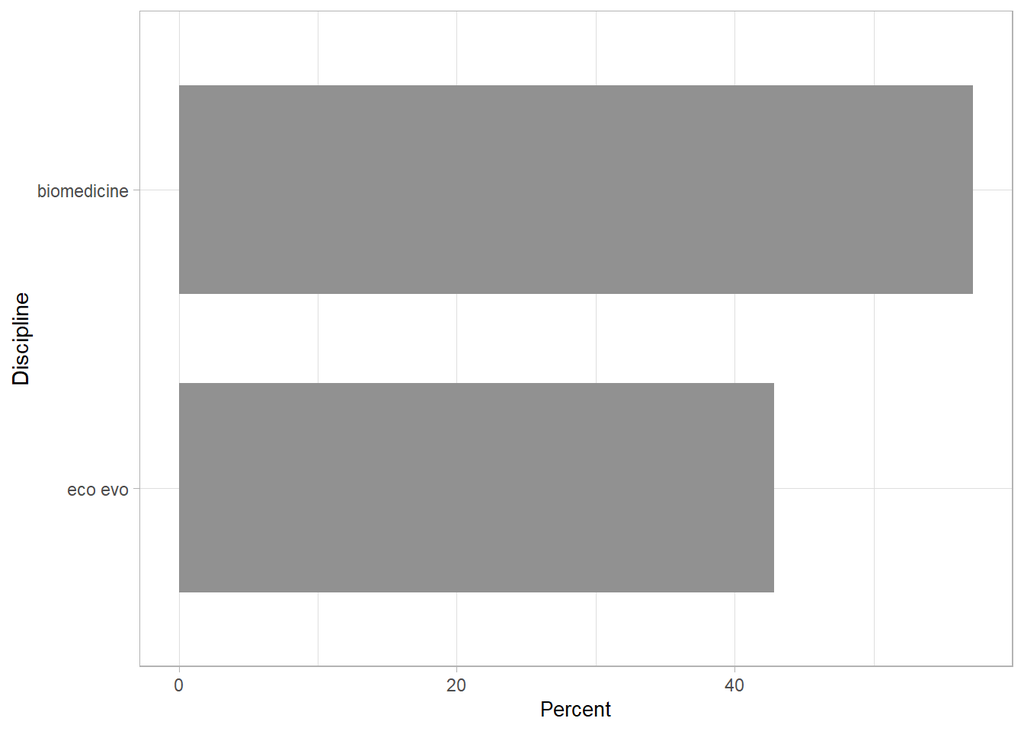

```r
count_discipline <-Review_info %>% count(controlled_vocab_discipline) %>% arrange(desc(n))
percent_discipline <- count_discipline %>% mutate(percent = (n/sum(n))*100)
percent_discipline$controlled_vocab_discipline <- factor(percent_discipline$controlled_vocab_discipline, level = percent_discipline$controlled_vocab_discipline[order(percent_discipline$n, decreasing = FALSE)])

ggplot(percent_discipline, aes(x = controlled_vocab_discipline, y = percent)) +
  geom_col(aes(fill = ""), width = 0.7) +
  theme_light() +
  coord_flip() +
  scale_y_continuous(name = "Percent") +
  xlab("Discipline") +
  scale_fill_manual(values = c("#919191")) +
  theme(legend.position = "none", axis.title.x = element_text(size = 10))
```

### Inter- vs trans-generational effects within and between disciplines

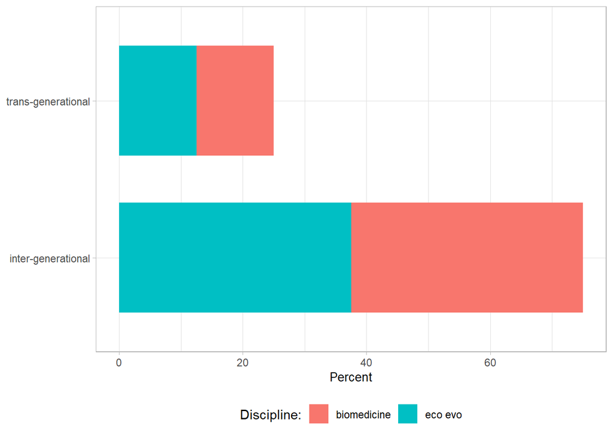

```r
Merged_inter_vs_trans <- merge(Inter_vs_trans_info, Review_info)

count_inter_vs_trans <- Merged_inter_vs_trans %>% count(controlled_vocab_inter_vs_trans, by = controlled_vocab_discipline ) %>% arrange(desc(n))
percent_inter_vs_trans <- count_inter_vs_trans %>% mutate(percent = (n/sum(n))*100)

percent_inter_vs_trans <-percent_inter_vs_trans %>%
  rename(
    controlled_vocab_discipline = by
  )

ggplot(percent_inter_vs_trans, aes(x = controlled_vocab_inter_vs_trans, y = percent)) +
  geom_col(aes(fill = controlled_vocab_discipline), width = 0.7) +
  theme_light() +
  coord_flip() +
  scale_y_continuous(name = "Percent") +
  theme(legend.position = "bottom", axis.title.x = element_text(size = 10), axis.title.y = element_blank()) +
  guides(fill=guide_legend(title="Discipline:"))
```

#### Table showing the original data code, the controlled vacabularly used, and a description of what the controlled vocabulary means.

Note that the description often equals controlled vocab but this is not always the case for more complicated elements.

```r
Inter_vs_trans_info_unique <- Inter_vs_trans_info %>%
  select(
    inter_vs_trans_code, controlled_vocab_inter_vs_trans, description
  )
unique(Inter_vs_trans_code_info) %>% arrange(inter_vs_trans_code)
```

| inter_vs_trans_code | controlled_vocab_inter_vs_trans | description |
| --- | --- | --- |
| 1 | inter-generational | inter-generational |
| 2 | trans-generational | trans-generational |
| 3 | unclear | unclear |

### Descendant generations within and between disciplines

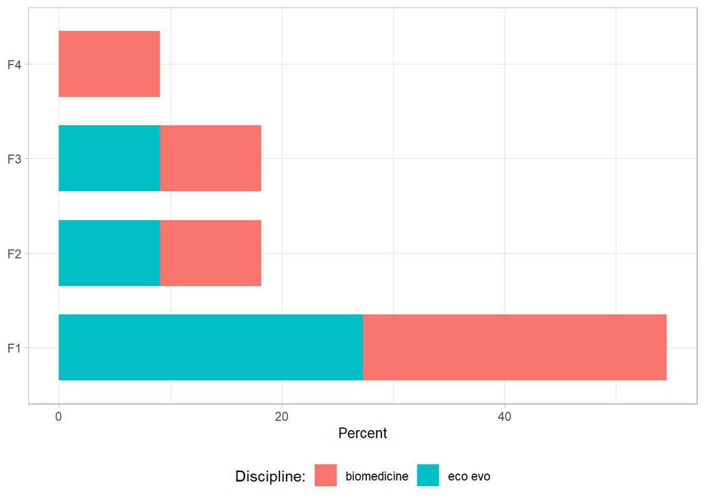

```r
merged_descendant_generat <- merge(Descendant_generat_info, Review_info)

count_descendant_generat <- merged_descendant_generat %>% count(controlled_vocab_descendant_generat, by = controlled_vocab_discipline) %>% arrange(desc(n))
percent_descendant_generat <- count_descendant_generat %>% mutate(percent = (n/sum(n))*100)

percent_descendant_generat <- percent_descendant_generat %>%
  rename (
    controlled_vocab_discipline = by
  )

ggplot(percent_descendant_generat, aes(x = controlled_vocab_descendant_generat, y = percent)) +
  geom_col(aes(fill = controlled_vocab_discipline), width = 0.7) +
  theme_light() +
  coord_flip() +
  scale_y_continuous(name = "Percent") +
  theme(legend.position = "bottom", axis.title.x = element_text(size = 10), axis.title.y = element_blank()) +
  guides(fill=guide_legend(title="Discipline:"))
```

#### Table showing the original data code, the controlled vacabularly used, and a description of what the controlled vocabulary means.

Note that the description often equals controlled vocab but this is not always the case for more complicated elements.

```r
Descendant_generat_info_unique <- Descendant_generat_info %>%
  select(
    descendant_generat_code, controlled_vocab_descendant_generat, description
  )
unique(Descendant_generat_info_unique) %>% arrange(descendant_generat_code)
```

| descendant_generat_code | controlled_vocab_descendant_generat | description |
| --- | --- | --- |
| 1 | F1 | F1 |
| 2 | F2 | F2 |
| 3 | F3 | F3 |
| 4 | F4 | F4 |

### Terminology used within and between disciplines

I.e., does the use of inter- and trans-generational inheritance match our definitions (see Fig. 1 of protocol)

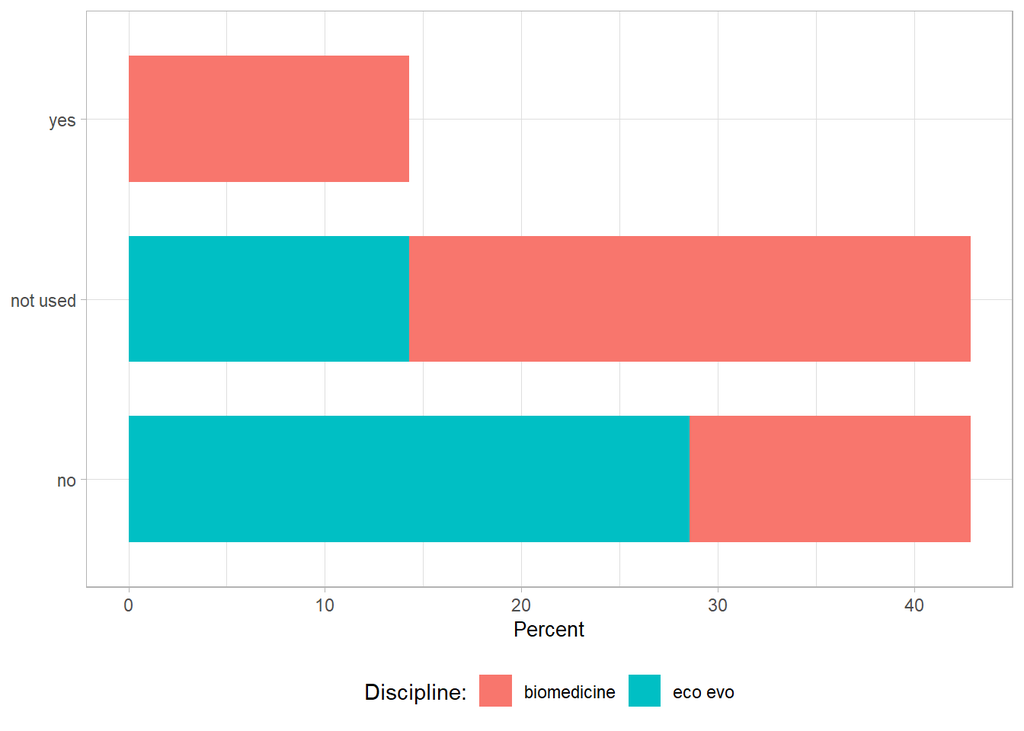

```r
count_terminology <- Review_info %>% count(controlled_vocab_terminology, by = controlled_vocab_discipline) %>% arrange(desc(n))
percent_terminology <- count_terminology %>% mutate(percent = (n/sum(n))*100)

percent_terminology<- percent_terminology %>%
  rename(
    controlled_vocab_discipline = by
  )

ggplot(percent_terminology, aes(x = controlled_vocab_terminology, y = percent)) +
  geom_col(aes(fill = controlled_vocab_discipline), width = 0.7) +
  theme_light() +
  coord_flip() +
  scale_y_continuous(name = "Percent") +
  theme(legend.position = "bottom", axis.title.x = element_text(size = 10), axis.title.y = element_blank()) +
  guides(fill=guide_legend(title="Discipline:"))
```

#### Table showing the original data code, the controlled vacabularly used, and a description of what the controlled vocabulary means.

Note that the description often equals controlled vocab but this is not always the case for more complicated elements.

```r
terminology_code_unique <- Review_info %>%
  select(
    terminology_code, controlled_vocab_terminology, description_terminology
  )
unique(terminology_code_unique) %>% arrange(terminology_code)
```

| terminology_code | controlled_vocab_terminology | description_terminology |
| --- | --- | --- |
| 1 | yes | yes |
| 2 | no | no |
| 3 | not used | does not use these terms |

### Types of non-genetic transmission within and between disciplines

I.e., are the non-genetic effects conferred through the matriline or patriline etc.

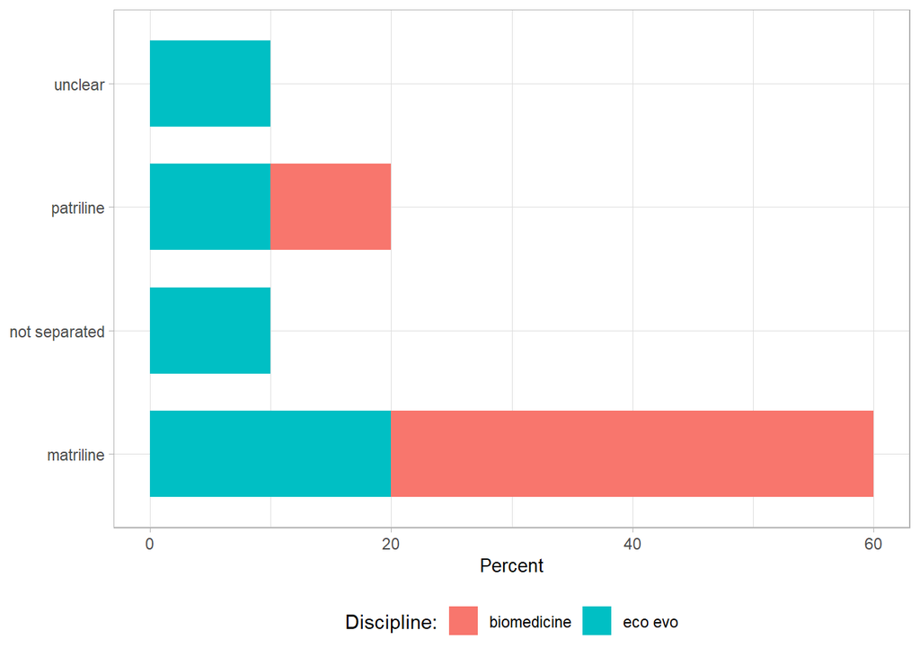

```r
Merged_transmission_info <- merge(Transmission_info, Review_info)

count_transmission <- Merged_transmission_info %>%  count(controlled_vocab_transmission, by = controlled_vocab_discipline) %>% arrange(desc(n))
percent_transmission <- count_transmission %>% mutate(percent = (n/sum(n))*100)

percent_transmission <-percent_transmission %>%
  rename(
    controlled_vocab_discipline = by
  )

ggplot(percent_transmission, aes(x = controlled_vocab_transmission, y = percent)) +
  geom_col(aes(fill = controlled_vocab_discipline), width = 0.7) +
  theme_light() +
  coord_flip() +
  scale_y_continuous(name = "Percent") +
  theme(legend.position = "bottom", axis.title.x = element_text(size = 10), axis.title.y = element_blank()) +
  guides(fill=guide_legend(title="Discipline:"))
```

#### Table showing the original data code, the controlled vacabularly used, and a description of what the controlled vocabulary means.

Note that the description often equals controlled vocab but this is not always the case for more complicated elements.

```r
Transmission_info_unique <- Transmission_info %>%
  select(
    transmission_code, controlled_vocab_transmission, description
  )
unique(Transmission_info_unique) %>% arrange(transmission_code)
```

| transmission_code | controlled_vocab_transmission | description |
| --- | --- | --- |
| 1 | matriline | matriline |
| 2 | patriline | patriline |
| 3 | not separated | not separated (i.e., the primary studies used do not enable matriline and patriline effects to be distinguished) |
| 4 | unclear | unclear/unspecefied |

### F0 environmental manipulations within and between disciplines

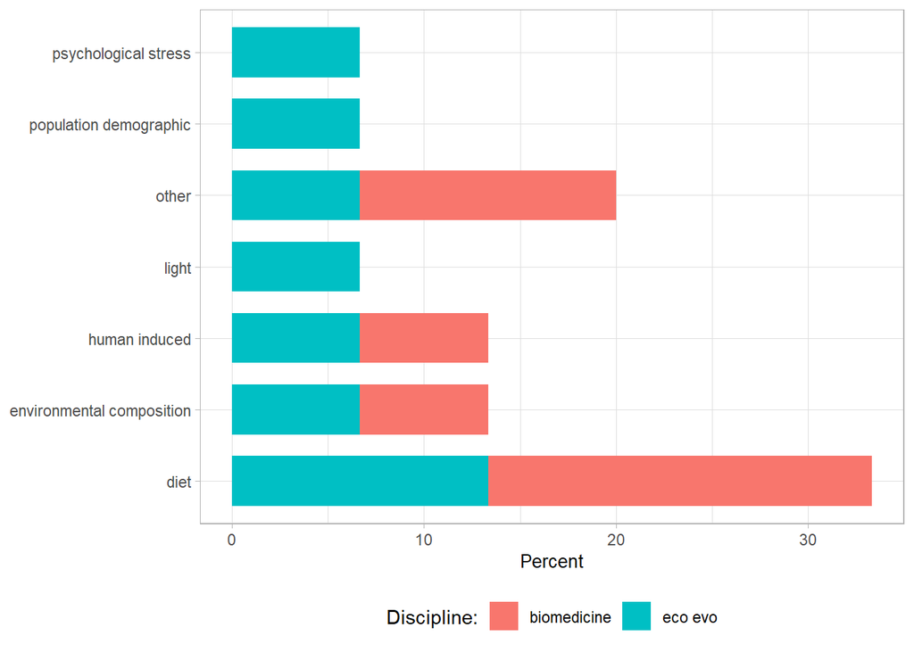

```r
merged_F0_env <- merge(F0_env_info, Review_info)

count_F0_env<- merged_F0_env %>% count(controlled_vocab_F0_env, by = controlled_vocab_discipline ) %>% arrange(desc(n))
percent_F0_env <- count_F0_env %>% mutate(percent = (n/sum(n))*100)

percent_F0_env <-percent_F0_env %>%
  rename(
    controlled_vocab_discipline = by
  )

ggplot(percent_F0_env, aes(x = controlled_vocab_F0_env, y = percent)) +
  geom_col(aes(fill = controlled_vocab_discipline), width = 0.7) +
  theme_light() +
  coord_flip() +
  scale_y_continuous(name = "Percent") +
  theme(legend.position = "bottom", axis.title.x = element_text(size = 10), axis.title.y = element_blank()) +
  guides(fill=guide_legend(title="Discipline:"))
```

#### Table showing the original data code, the controlled vacabularly used, and a description of what the controlled vocabulary means.

Note that the description often equals controlled vocab but this is not always the case for more complicated elements.

```r
F0_env_info_unique <- F0_env_info %>%
  select(
    F0_env_code, controlled_vocab_F0_env, description
  )
unique(F0_env_info_unique) %>% arrange(F0_env_code)
```

| F0_env_code | controlled_vocab_F0_env | description |
| --- | --- | --- |
| 1 | diet | diet |
| 2 | human induced | human induced pollutant/toxin |
| 3 | environmental composition | natural variation in environmental composition (e.g., salt, nitrogen etc) |
| 4 | psychological stress | psychological stress (e.g., post-natal separation) |
| 7 | population demographic | differences in population demographics (e.g., population density, predators, sex-ratio etc.) |
| 8 | light | light and/or photoperiod |
| 9 | other | other/unclear |

### Environmental effect direction within and between disciplines

I.e., are the effects of enviroment predicted to have negative, possitive, or neutral effects on offspring phenotype

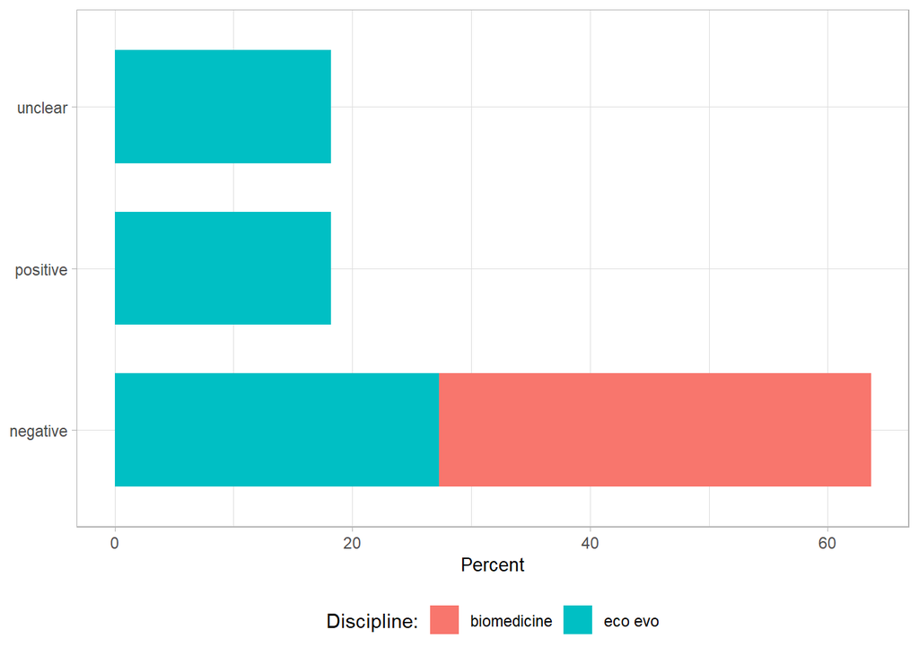

```r
merged_env_eff <- merge(Env_eff_diection_info, Review_info)

count_env_eff <- merged_env_eff %>% count(controlled_vocab_env_eff_direction, by = controlled_vocab_discipline) %>% arrange(desc(n))
percent_env_eff <- count_env_eff %>% mutate(percent = (n/sum(n))*100)

percent_env_eff <-percent_env_eff %>%
  rename(
    controlled_vocab_discipline = by
  )

ggplot(percent_env_eff, aes(x = controlled_vocab_env_eff_direction, y = percent)) +
  geom_col(aes(fill = controlled_vocab_discipline), width = 0.7) +
  theme_light() +
  coord_flip() +
  scale_y_continuous(name = "Percent") +
  theme(legend.position = "bottom", axis.title.x = element_text(size = 10), axis.title.y = element_blank()) +
  guides(fill=guide_legend(title="Discipline:"))
```

#### Table showing the original data code, the controlled vacabularly used, and a description of what the controlled vocabulary means.

Note that the description often equals controlled vocab but this is not always the case for more complicated elements.

```r
Env_eff_direction_info_unique <- Env_eff_diection_info %>%
  select(
    env_eff_direction_code, controlled_vocab_env_eff_direction, description
  )
unique(Env_eff_direction_info_unique) %>% arrange(env_eff_direction_code)
```

| env_eff_direction_code | controlled_vocab_env_eff_direction | description |
| --- | --- | --- |
| 1 | negative | negative |
| 2 | positive | positive |
| 3 | unclear | unclear |

### F0 environmental exposure timing within and between disciplines

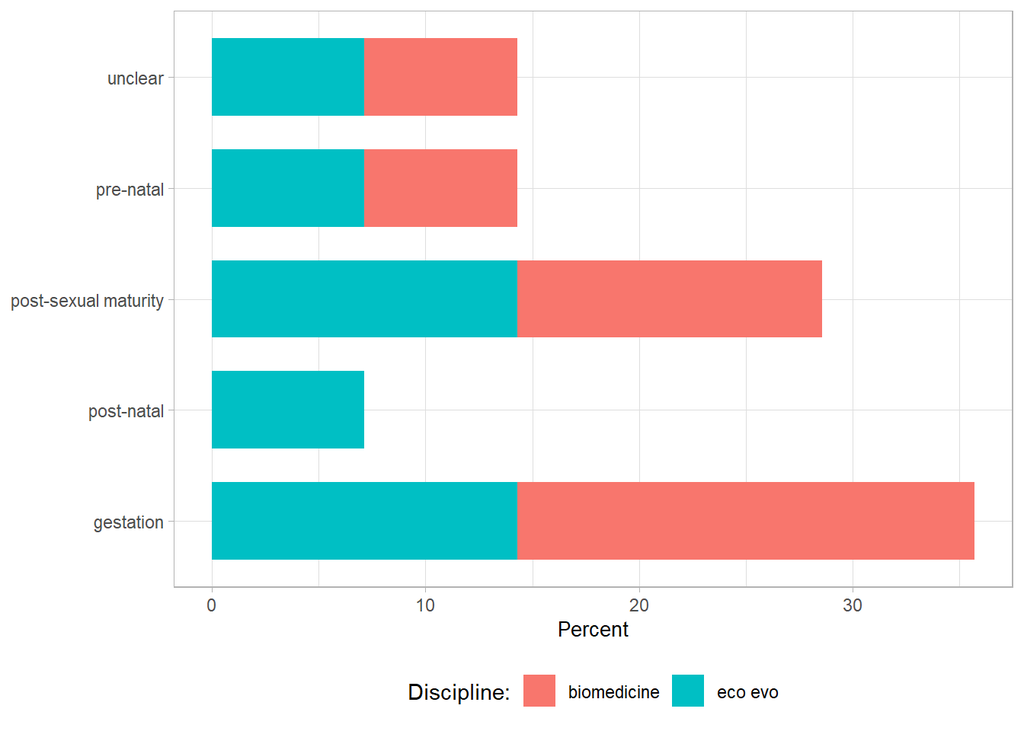

```r
merged_exposure_timing <- merge(Exposure_timing_info, Review_info)

count_exposure_timing <- merged_exposure_timing %>% count(controlled_vocab_exposure_timing, by = controlled_vocab_discipline) %>% arrange(desc(n))
percent_exposure_timing <- count_exposure_timing %>% mutate(percent = (n/sum(n))*100)

percent_exposure_timing <-percent_exposure_timing %>%
  rename (
    controlled_vocab_discipline = by
  )

ggplot(percent_exposure_timing, aes(x = controlled_vocab_exposure_timing, y = percent)) +
  geom_col(aes(fill = controlled_vocab_discipline), width = 0.7) +
  theme_light() +
  coord_flip() +
  scale_y_continuous(name = "Percent") +
  theme(legend.position = "bottom", axis.title.x = element_text(size = 10), axis.title.y = element_blank()) +
  guides(fill=guide_legend(title="Discipline:"))
```

#### Table showing the original data code, the controlled vacabularly used, and a description of what the controlled vocabulary means.

Note that the description often equals controlled vocab but this is not always the case for more complicated elements.

```r
Exposure_timing_info_unique<- Exposure_timing_info %>%
  select(
    exposure_timing_code, controlled_vocab_exposure_timing, description
  )
unique(Exposure_timing_info_unique) %>% arrange(exposure_timing_code)
```

| exposure_timing_code | controlled_vocab_exposure_timing | description |
| --- | --- | --- |
| 1 | pre-natal | pre-natally |
| 2 | post-natal | post-natal before sexual maturity |
| 3 | post-sexual maturity | after sexual maturity but before gestation |
| 4 | gestation | during gestation |
| 5 | unclear | other/unclear |

### Descendant traits within and between disciplines

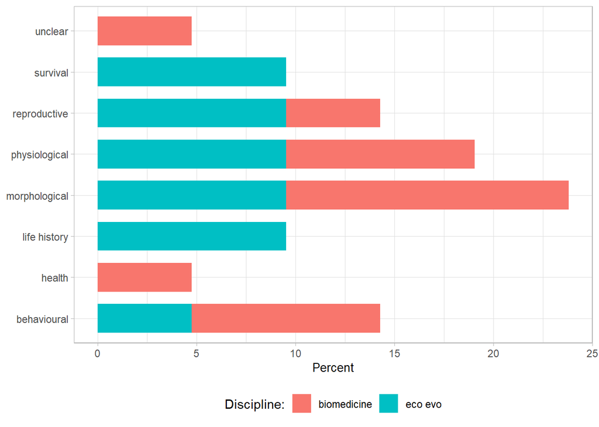

```r
merged_descendant_trait <- merge(Descendant_trait_info, Review_info)

count_descendant_trait <- merged_descendant_trait %>% count(controlled_vocab_descendant_trait, by = controlled_vocab_discipline) %>% arrange(desc(n))
percent_descendant_trait <- count_descendant_trait %>% mutate(percent = (n/sum(n))*100)

percent_descendant_trait <- percent_descendant_trait %>%
  rename(
    controlled_vocab_discipline = by
  )

ggplot(percent_descendant_trait, aes(x = controlled_vocab_descendant_trait, y = percent)) +
  geom_col(aes(fill = controlled_vocab_discipline), width = 0.7) +
  theme_light() +
  coord_flip() +
  scale_y_continuous(name = "Percent") +
  theme(legend.position = "bottom", axis.title.x = element_text(size = 10), axis.title.y = element_blank()) +
  guides(fill=guide_legend(title="Discipline:"))
```

#### Table showing the original data code, the controlled vacabularly used, and a description of what the controlled vocabulary means.

Note that the description often equals controlled vocab but this is not always the case for more complicated elements.

```r
Descendant_trait_info_unique<-Descendant_trait_info %>%
  select(
    descendant_trait_code, controlled_vocab_descendant_trait, description
  )
unique(Descendant_trait_info_unique) %>% arrange(descendant_trait_code)
```

| descendant_trait_code | controlled_vocab_descendant_trait | description |
| --- | --- | --- |
| 1 | physiological | physiological (e.g., immune function, insulin levels, hormone levels) |
| 2 | morphological | morphological (e.g., body size, adiposity, colouration) |
| 3 | reproductive | reproductive (e.g., fecundity and sexual trait measures) |
| 4 | life history | life-history (e.g., developmental rate, aging and lifespan), 5 = descendant survival/aging (must be post-natally) |
| 5 | survival | descendant survival/aging (must be post-natally) |
| 6 | behavioural | behavioural (e.g., response to stimuli, anxiety, learning) |
| 8 | health | health and disease (e.g., disease prevalence ) |
| 9 | unclear | other/unclear |

### Descendant sex within and between disciplines

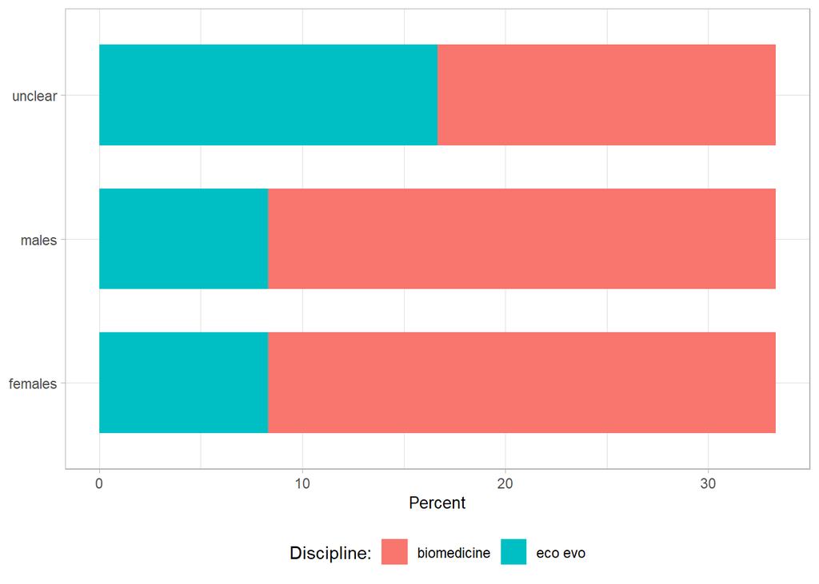

```r
merged_descendant_sex <- merge(Descendant_sex_info, Review_info)

count_descendant_sex <- merged_descendant_sex %>% count(controlled_vocab_descendant_sex, by = controlled_vocab_discipline) %>% arrange(desc(n))
percent_descendant_sex <- count_descendant_sex  %>% mutate(percent = (n/sum(n))*100)

percent_descendant_sex <- percent_descendant_sex %>%
  rename(
    controlled_vocab_discipline = by
           )

ggplot(percent_descendant_sex, aes(x = controlled_vocab_descendant_sex, y = percent)) +
  geom_col(aes(fill = controlled_vocab_discipline), width = 0.7) +
  theme_light() +
  coord_flip() +
  scale_y_continuous(name = "Percent") +
  theme(legend.position = "bottom", axis.title.x = element_text(size = 10), axis.title.y = element_blank()) +
  guides(fill=guide_legend(title="Discipline:"))
```

#### Table showing the original data code, the controlled vacabularly used, and a description of what the controlled vocabulary means.

Note that the description often equals controlled vocab but this is not always the case for more complicated elements.

```r
Descendant_sex_info_unique<- Descendant_sex_info %>%
  select(
    descendant_sex_code, controlled_vocab_descendant_sex, description
  )
unique(Descendant_sex_info_unique) %>% arrange(descendant_sex_code)
```

| descendant_sex_code | controlled_vocab_descendant_sex | description |
| --- | --- | --- |
| 1 | males | males |
| 2 | females | females |
| 3 | unclear | unclear |

### Descendant age within and between disciplines

**Note:** We excluded SRs that solely focused on fetal traits in descendants. However, some broader SRs included primary studies that mearured fetal traits. This was therefore coeded in our data.

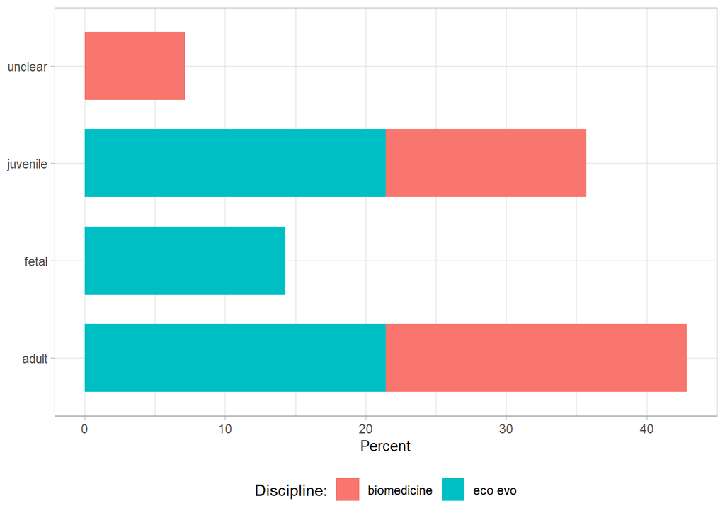

```r
merged_descendant_age <- merge(Descendant_age_info, Review_info)

count_descendant_age <- merged_descendant_age %>% count(controlled_vocab_descendant_age, by = controlled_vocab_discipline) %>% arrange(desc(n))
percent_descendant_age <- count_descendant_age %>% mutate(percent = (n/sum(n))*100)

percent_descendant_age <- percent_descendant_age %>%
  rename(
    controlled_vocab_discipline = by
  )

ggplot(percent_descendant_age, aes(x = controlled_vocab_descendant_age, y = percent)) +
  geom_col(aes(fill = controlled_vocab_discipline), width = 0.7) +
  theme_light() +
  coord_flip() +
  scale_y_continuous(name = "Percent") +
  theme(legend.position = "bottom", axis.title.x = element_text(size = 10), axis.title.y = element_blank()) +
  guides(fill=guide_legend(title="Discipline:"))
```

#### Table showing the original data code, the controlled vacabularly used, and a description of what the controlled vocabulary means.

Note that the description often equals controlled vocab but this is not always the case for more complicated elements.

```r
Descendant_age_info_unique<- Descendant_age_info %>%
  select(
    descendant_age_code, controlled_vocab_descendant_age, description
  )
unique(Descendant_age_info_unique) %>% arrange(descendant_age_code)
```

| descendant_age_code | controlled_vocab_descendant_age | description |
| --- | --- | --- |
| 1 | fetal | fetal/embryonic |
| 2 | juvenile | juvenile (post-embryonic/birth prior to sexual maturity) |
| 3 | adult | adult |
| 5 | unclear | other/unclear |

### Higher taxononmic groups within and between disciplines

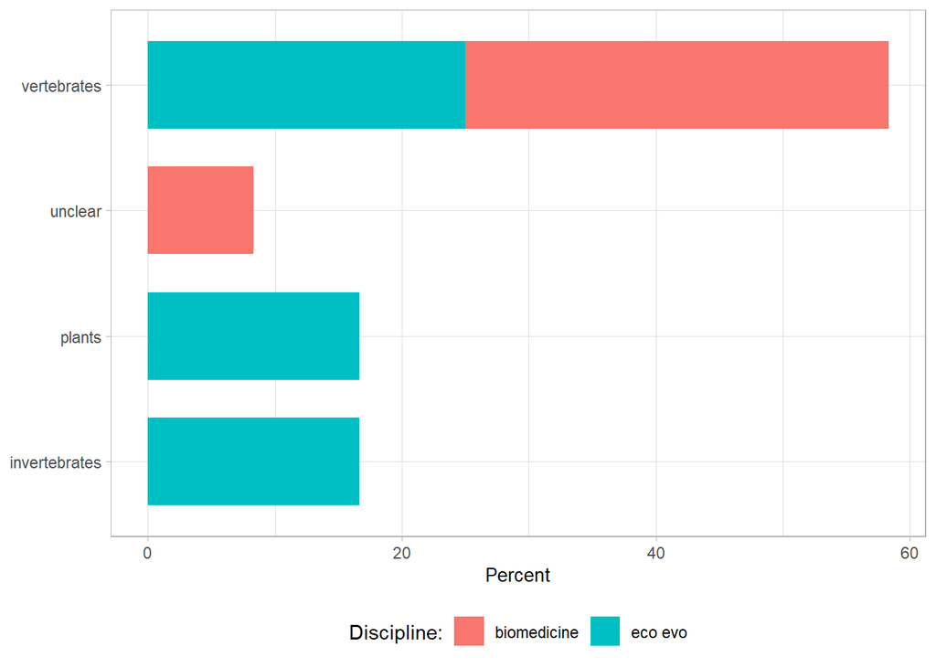

```r
Merged_higher_taxon <- merge(Higher_taxon_info, Review_info)

count_higher_taxon <- Merged_higher_taxon %>% count(controlled_vocab_taxon, by = controlled_vocab_discipline) %>% arrange(desc(n))
percent_higher_taxon <- count_higher_taxon %>% mutate(percent = (n/sum(n))*100)

percent_higher_taxon<-percent_higher_taxon %>%
  rename(
    controlled_vocab_discipline = by
  )

ggplot(percent_higher_taxon, aes(x = controlled_vocab_taxon, y = percent)) +
  geom_col(aes(fill = controlled_vocab_discipline), width = 0.7) +
  theme_light() +
  coord_flip() +
  scale_y_continuous(name = "Percent") +
  theme(legend.position = "bottom", axis.title.x = element_text(size = 10), axis.title.y = element_blank()) +
  guides(fill=guide_legend(title="Discipline:"))
```

#### Table showing the original data code, the controlled vacabularly used, and a description of what the controlled vocabulary means.

Note that the description often equals controlled vocab but this is not always the case for more complicated elements.

```r
Higher_taxon_info_unique<- Higher_taxon_info %>%
  select(
    taxon_code, controlled_vocab_taxon, description
  )
unique(Higher_taxon_info_unique) %>% arrange(taxon_code)
```

| taxon_code | controlled_vocab_taxon | description |
| --- | --- | --- |
| 1 | vertebrates | vertebrates |
| 2 | invertebrates | invertebrates |
| 3 | plants | plants |
| 5 | unclear | unclear |

### Descendent generation vs terminology use across disciplines

Does the terminology used (i.e., inter- vs trans-generational) match our definition (based on generation, sex and taxa) within the descendant generations examined

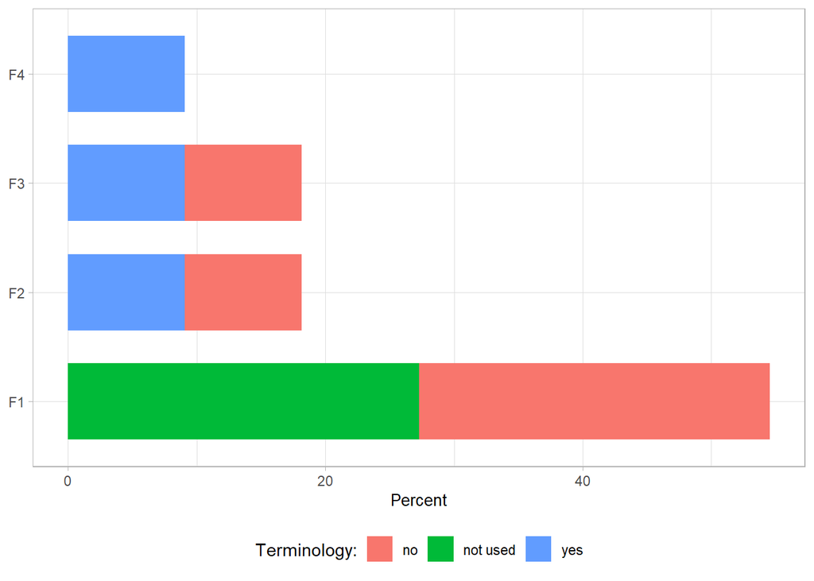

```r
generat_terminology <- merge(Descendant_generat_info, Review_info)

count_generat_terminology <- generat_terminology %>% count(controlled_vocab_descendant_generat, by = controlled_vocab_terminology) %>% arrange(desc(n))
percent_generat_terminology <- count_generat_terminology %>% mutate(percent = (n/sum(n))*100)

percent_generat_terminology<-percent_generat_terminology %>%
  rename(
    controlled_vocab_terminology = by
  )

ggplot(percent_generat_terminology, aes(x = controlled_vocab_descendant_generat, y = percent)) +
  geom_col(aes(fill = controlled_vocab_terminology), width = 0.7) +
  theme_light() +
  coord_flip() +
  scale_y_continuous(name = "Percent") +
  theme(legend.position = "bottom", axis.title.x = element_text(size = 10), axis.title.y = element_blank()) +
  guides(fill=guide_legend(title="Terminology:"))
```

### Time trend of the number of SRs per year

Note that is figure will look considerably different on the full data

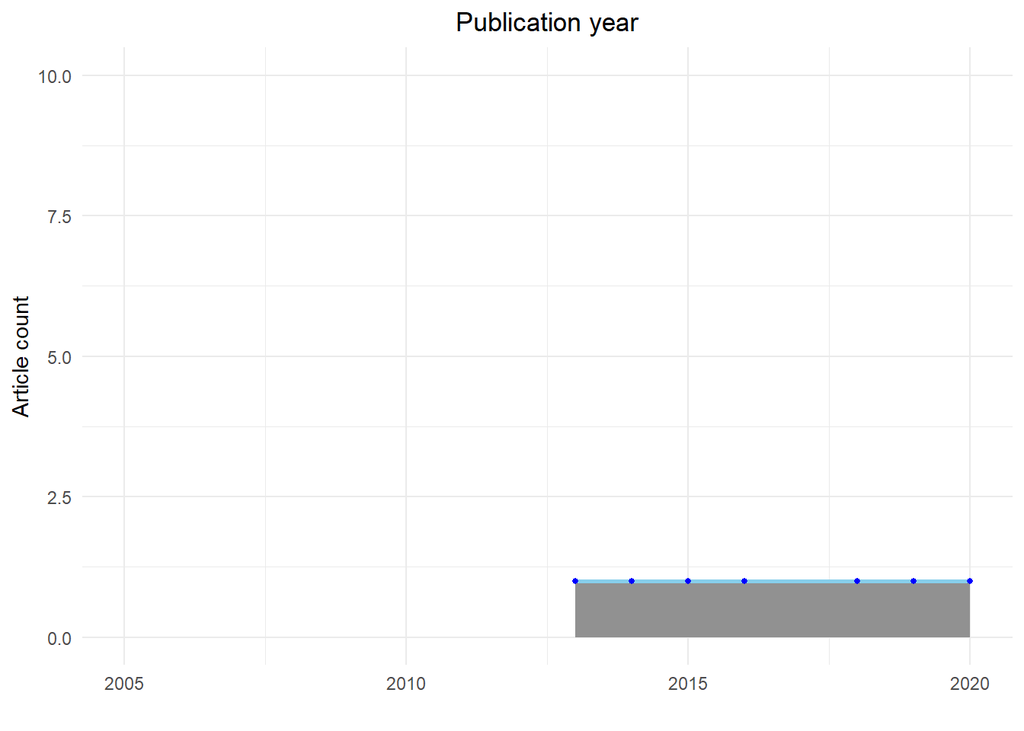

```r
Publication_info %>% count(year) %>% ggplot(aes(x = year, y = n)) +
  geom_area(fill = '#919191', alpha = 1) +
  geom_line(color = 'skyblue', size = 1) +
  geom_point(size=1, color = 'blue') +
  theme_minimal() +
  scale_x_continuous(name = "", limits = c(2005, 2020)) +
  scale_y_continuous(name = "Article count", limits = c(0, 10)) +
  ggtitle("Publication year") +
  theme(plot.title = element_text(hjust = 0.5))
```

## Adressing objective 3

3. Conduct bibliometric analyses of co-author networks and common terminology use across and within disciplines.

The following visualisations allow us to view bibliometric patterns from data exported directly from scopus. We are able to view common keyword use, author networks, affiliations, and citation patterns.

### Author, country, and citation summary plots

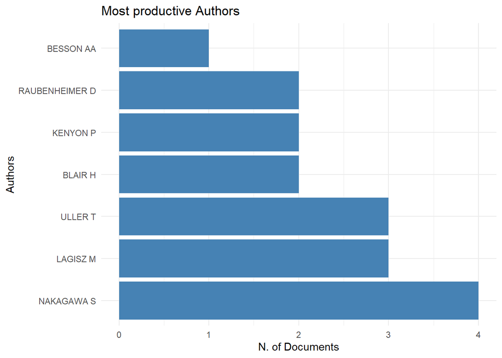

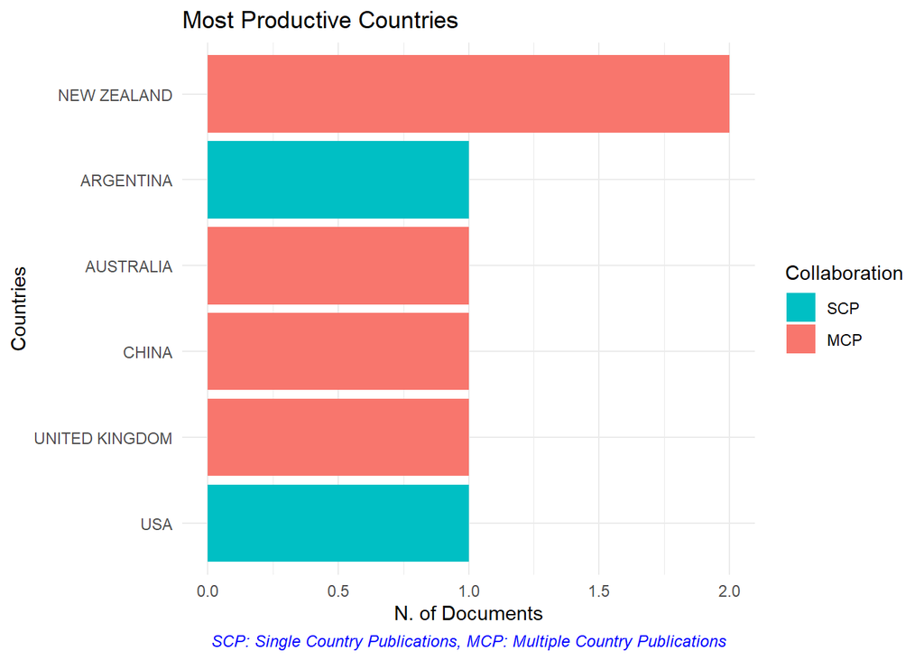

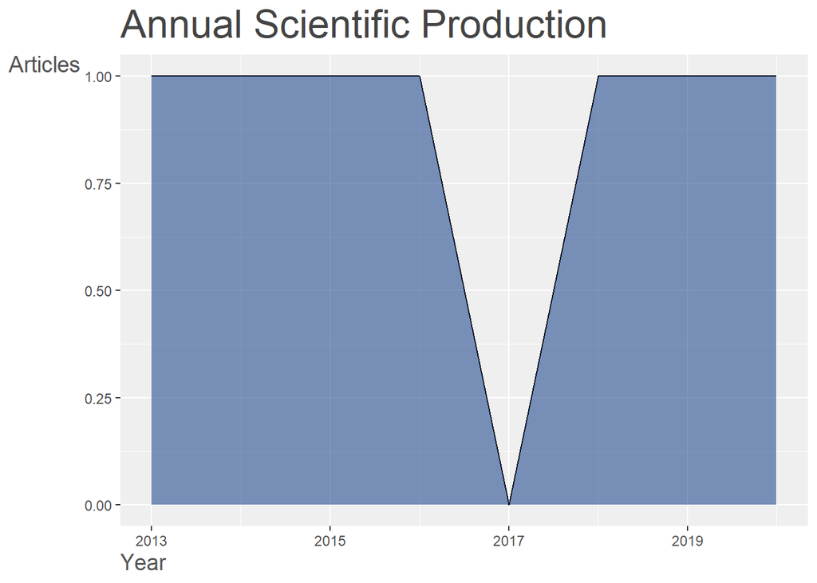

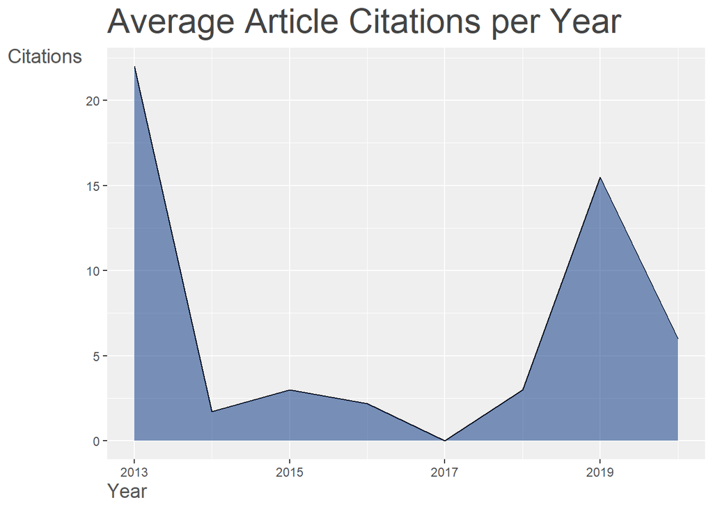

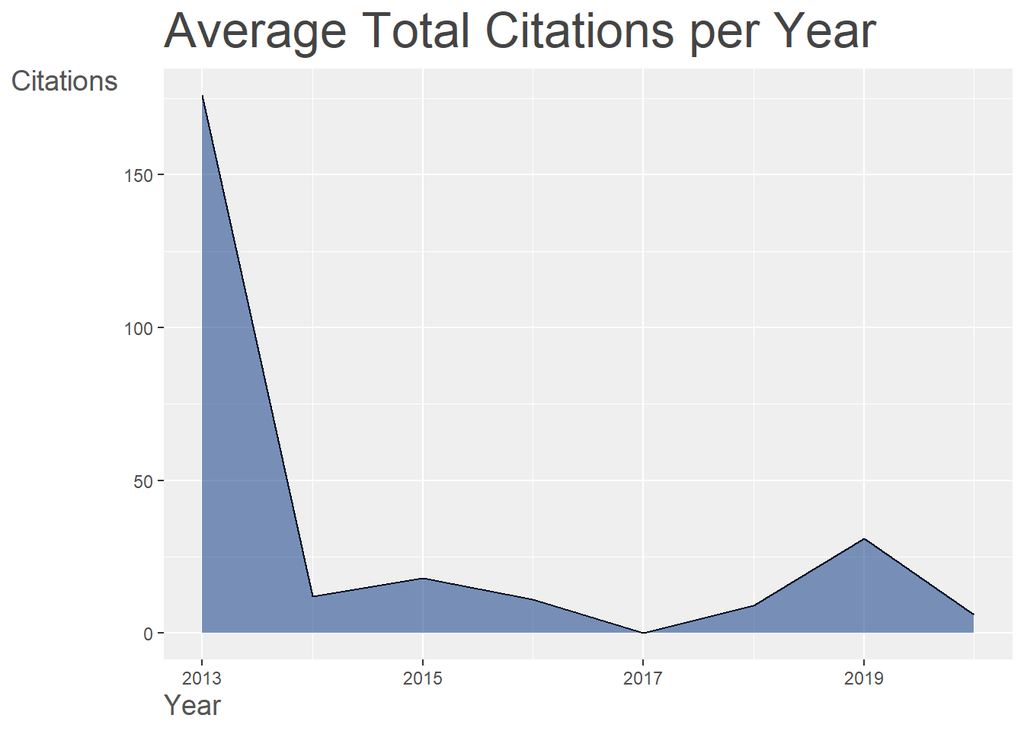

```r
results1 <- biblioAnalysis(bib) #run basic standard descriptive analysis of the dataset (data frame)
summary(results1, k = 7, pause = F, width = 130) #produces a sequence of standard summary tables displayed in the console

plot(results1, k = 7, pause = F)
```

### Keyword matrix plot

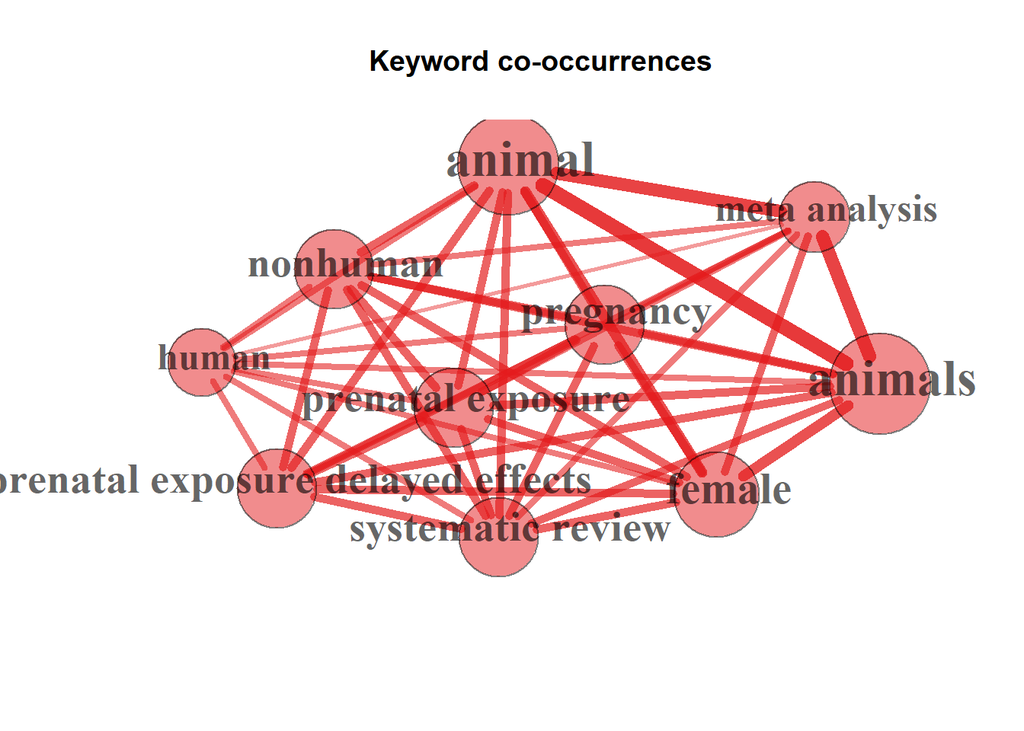

```r
NetMatrix_keywords <- biblioNetwork(bib, analysis = "co-occurrences", network = "keywords", sep = ";")
NetMatrix_keywords_plot <- networkPlot(NetMatrix_keywords, normalize="association", n = 10, Title = "Keyword co-occurrences", type = "fruchterman", size.cex = TRUE, size = 30, remove.multiple = F, edgesize = 10, labelsize = 3, label.cex = TRUE,edges.min = 2, cluster = "optimal")
```

### Thematic map

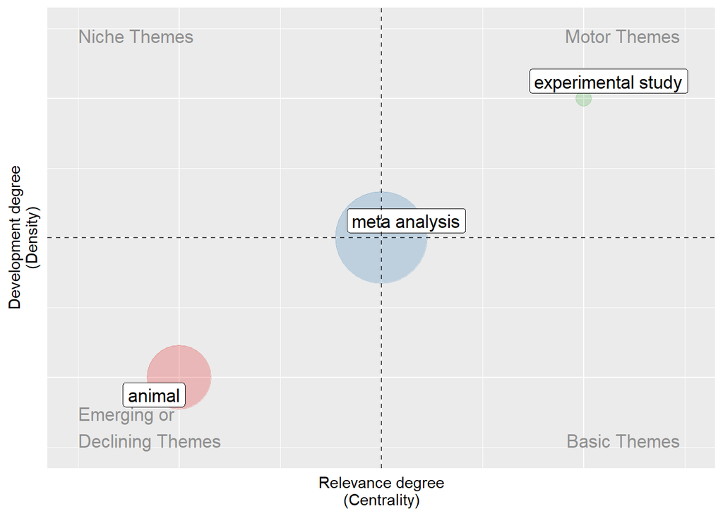

```r
map_thematic <- thematicMap(bib, field = "ID", n = 1000, minfreq = 5, stemming = FALSE, size = 0.5, n.labels = 1, repel = TRUE)
plot(map_thematic$map)
```

### Author collaboration network

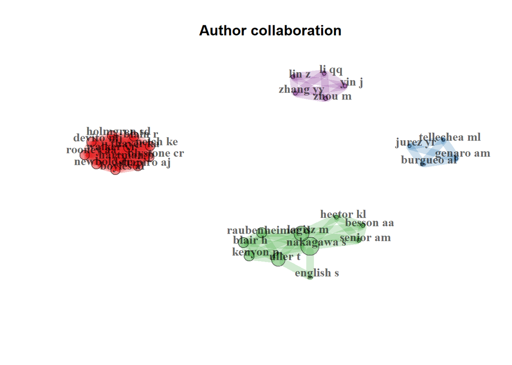

```r
NetMatrix_authors <- biblioNetwork(bib, analysis = "collaboration",  network = "authors", sep = ";")
NetMatrix_authors_plot <- networkPlot(NetMatrix_authors,  n = 50, Title = "Author collaboration", type = "auto", size = 10, size.cex = TRUE, edgesize = 10, labelsize = 1) #note there are potentially some mistakes in authors initials
```

### Country collaboration network

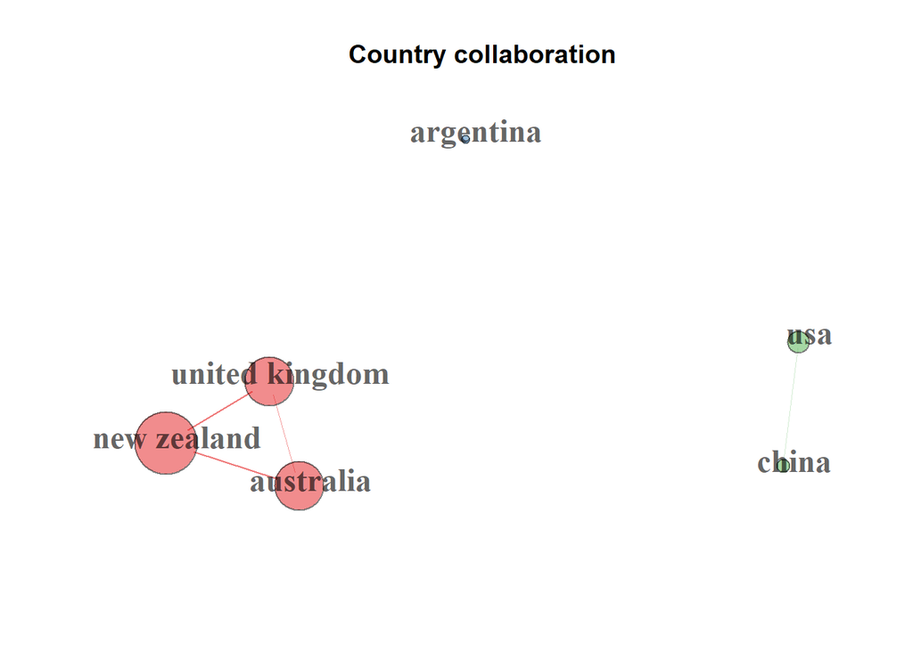

```r
bib_sco2 <- metaTagExtraction(bib, Field = "AU_CO", sep = ";") #we need to extract countries from the affiliations first
#bib_sco2$AU_CO[1:10]
NetMatrix_country <- biblioNetwork(bib_sco2, analysis = "collaboration", network = "countries", sep = ";")
NetMatrix_country_plot <-  networkPlot(NetMatrix_country, n = 50, Title = "Country collaboration", type = "auto", size=TRUE, remove.multiple=FALSE, labelsize=1.5)
```

## Addressing objective 4

4. Conduct a critical appraisal of the SR literature to assess the rigour, transparency, and risk of bias.

The following visualisations allow us to see the average scores across each CEESAT questions as well as how each individual SR scored for each CEESAT questions. This will allow us to assess the quality and Risk of Bias of the SR literature.

**Note:** CEESAT questions and scoring criteria can be found in Appendix_S3 on the open Science Framework https://osf.io/detvk/.

### Blinding paper ID and wrangling data into long format

Paper ID was blinded for the pilot but will not be blinded for the full study

```r
#blinding authors
Assessment$id <- paste("ID", c(1:length(Assessment$id)), sep = "")

#shortening column names
names(Assessment) <- gsub("CEESAT_", "", names(Assessment), fixed = TRUE)

#selecting only the columns with scores
#selecting only the columns with scores
Assessment_reduced <- select(Assessment, c("id", !ends_with("_comment")))

#wrangling data into long format
ceesat_long <- gather(Assessment_reduced, question, score, Q1.1:Q8.1, factor_key=TRUE)
```

### CEESAT score summary across SRs

This plot shows the average CEESAT score per question. CEESAT questions and scoring criteria can be found in Appendix_S3 on the open Science Framework https://osf.io/detvk/.

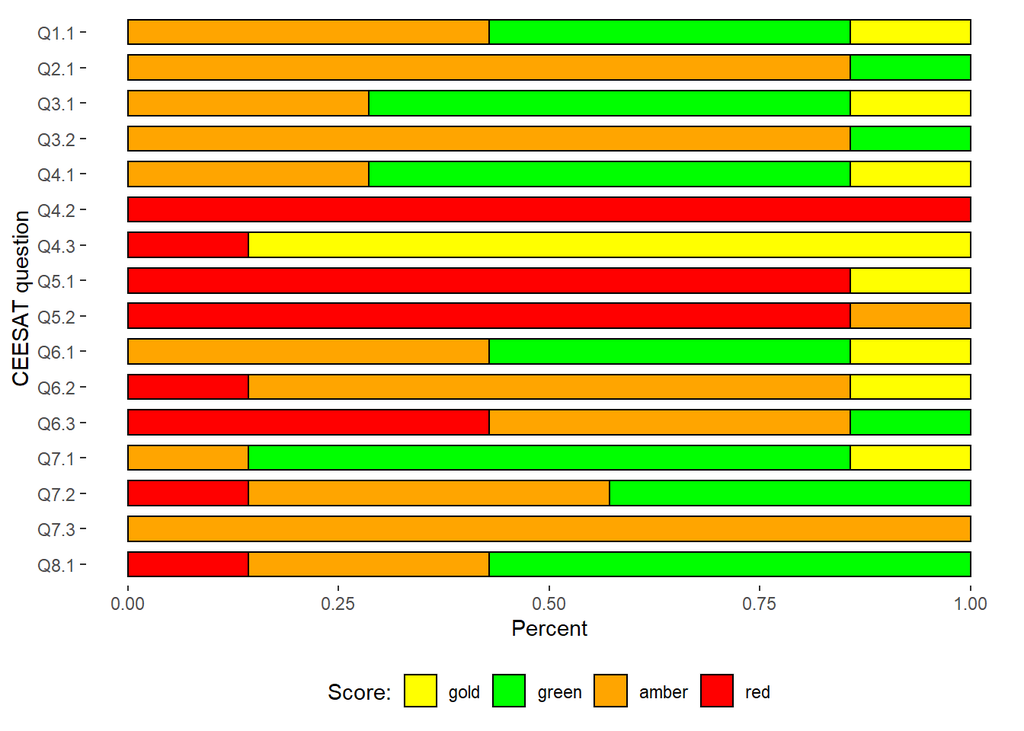

```r
#calculating the % of scores within each questions
count_ceesat_score <- ceesat_long %>% count(score, by = question)
percent_ceesat_score <- count_ceesat_score %>% mutate(percent = (n/sum(n))*100)

percent_ceesat_score <- percent_ceesat_score %>%
  rename(
    question = by
  )

percent_ceesat_score$question <- as.factor(percent_ceesat_score$question)
percent_ceesat_score$question <- factor(percent_ceesat_score$question, levels(percent_ceesat_score$question)[length(percent_ceesat_score$question):1]) #reverse the order of questions

percent_ceesat_score$score <- as.factor(percent_ceesat_score$score)
percent_ceesat_score$score <- factor(percent_ceesat_score$score, levels(percent_ceesat_score$score)[c(2,3,1,4)]) #set the order of levels for assessment scores:

summaryplot <- ggplot(data = percent_ceesat_score, x = question, y = percent) +
  geom_col(mapping = aes(x = question, y = percent, fill = score), width = 0.7,
           position = "fill", color = "black") +
  coord_flip(ylim = c(0, 1)) +
  guides(fill = guide_legend(reverse = TRUE)) +
  scale_fill_manual(values = c("yellow","green", "orange","red")) +
  theme(legend.position = "bottom", panel.grid.major = element_blank(),panel.grid.minor = element_blank(),panel.background = element_blank()) +
  ylab("Percent") + xlab("CEESAT question") +
  guides(fill=guide_legend(title="Score:"))

summaryplot
```

### Individual CEESAT Scores

This plot shows the CEESAT score per SR. CEESAT questions and scoring criteria can be found in Appendix_S3 on the open Science Framework https://osf.io/detvk/.

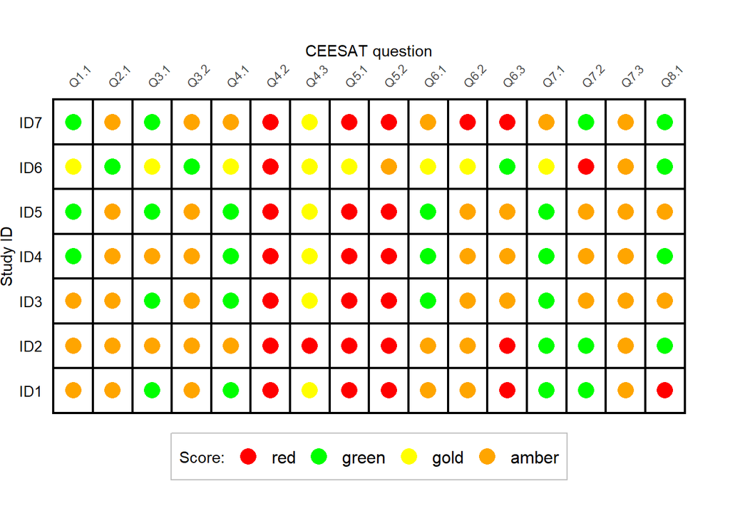

```r
scoresplot <- ggplot(data = ceesat_long, aes(y = id, x = question)) +
  geom_tile(color="black", fill="white", size = 0.8) +
  geom_point(aes(color = as.factor(score)), size = 5) +
  scale_x_discrete(position = "top") +
  guides(color = guide_legend(reverse = TRUE)) +
  scale_color_manual(values = c("orange","yellow","green","red" ), name = "Score:") +
  theme_minimal() +
  theme(panel.grid.major = element_blank(),
        panel.grid.minor = element_blank(),
        panel.background = element_blank(),
        legend.position = "bottom",
        legend.background = element_rect(linetype = "solid", colour = "grey"),
        legend.key.size = unit(0.75, "cm"),
        legend.text = element_text(size = 12),
        axis.text.y = element_text(size = 10, color = "black"),
        axis.text.x = element_text(angle = 45, hjust=0),
        plot.margin = unit(c(1,1,1,0), "cm")
  ) +
  ylab("Study ID") +
  xlab("CEESAT question")

scoresplot
```